# Clase 3 - Visualización de la información

Clase 3 - Práctica independiente

## Ejercicios EPH

1. Calcular el promedio del ingreso por ocupación principal (Variable **P21**) para **asalariados** con y sin **descuento jubilatorio** (Variable **PP07H**). Luego realizar un gráfico de barras donde se comparen ambos valores (para el 1er trimestre de 2017).

Pistas: Se deben filtrar previamente los ingresos mayores a 0 (**P21>0**).Chequear que ponderador corresponde utilizar

1. Graficar la distribución del ingreso por ocupación principal para Asalariados, Cuentapropistas y Patrones, con el tipo de gráfico Kernel  
   Pista: Usar la función **facet_wrap** para separar a cada una de las categorías ocupacionales)  
   Sugerencia: incorporar la línea `scale_x_continuous(limits = c(0,50000))` entre las capas del gráfico. ¿Qué cambió?
2. Hacer un gráfico boxplot de la distribución de edades de los asalariados con descuento jubilatorio, y de los asalariados sin descuento jubilatorio.
3. Uniendo las bases de los distintos trimestres, calcular el procentaje de asalariados sin descuento jubilatorio como $\frac{Asal. s/ desc jubil}{Asal. c/ desc jubil+ Asal.s/ desc jubil}$. Luego realizar un gráfico de linea con la evolución de este indicador

## [Gap Minder](https://www.gapminder.org/)

```r
library(gapminder)
```

```r
glimpse(gapminder)
```

```
Observations: 1,704
Variables: 6
$ country   <fct> Afghanistan, Afghanistan, Afghanistan, Afghanistan,...
$ continent <fct> Asia, Asia, Asia, Asia, Asia, Asia, Asia, Asia, Asi...
$ year      <int> 1952, 1957, 1962, 1967, 1972, 1977, 1982, 1987, 199...
$ lifeExp   <dbl> 28.801, 30.332, 31.997, 34.020, 36.088, 38.438, 39....
$ pop       <int> 8425333, 9240934, 10267083, 11537966, 13079460, 148...
$ gdpPercap <dbl> 779.4453, 820.8530, 853.1007, 836.1971, 739.9811, 7...
```

> Con esta info a mi se me ocurre este gráfico. Propongan otra forma de visualizar esta información.

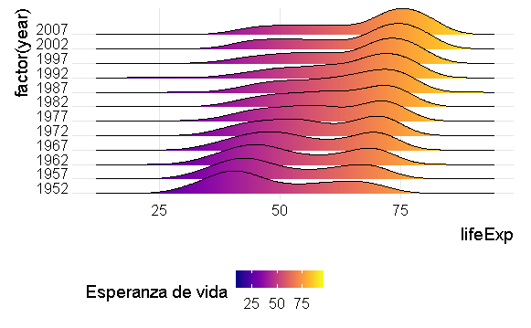

```r
library(ggridges)
library(viridis)
ggplot(gapminder, aes(x = lifeExp, y = factor(year), fill = ..x..)) +
  geom_density_ridges_gradient()+
  scale_y_discrete(expand = c(0.01, 0)) +
  scale_fill_viridis(name = "Esperanza de vida", option = "C")+
  theme_ridges()+
  theme(legend.position = 'bottom')
```